# Finding RSEs and Data scientists

This notebook looks at the words that RSEs use to describe themselves, and compares this to the words used in job adverts to recruit RSEs.

We use Twitter biography data to see how RSEs describe themselves, and an archive of job adverts from the RSE association web site to look at words used in recruiting.

## RSE job adverts

We used an archive of job adverts downloaded from the RSE job site, and remove stop words:

```r
xml<- read_xml("researchsoftwareengineersassociation.wordpress.2018-03-19.xml")
words<- xml %>% xml_text(trim=TRUE)
words<- strsplit(words, " ")
words<- words %>% tolower() %>% removeWords( c(words=stopwords(kind="en"),"will")) %>%
  removeNumbers() %>% removePunctuation() %>% strsplit(" ") %>% unlist() %>%
  stemDocument()
words<- words[nchar(words)<12 & nchar(words)>1]
```

## Twitter analysis

To see how RSEs describe themselves, we use look at followers of the ResearchSoftEng Twitter account as a seed; this is the official Twitter account of the RSE association. We assume that everyone following this is an RSE.

```r
rse_follows <- get_followers(account)
rse_follows_data <- lookup_users(rse_follows$user_id)
```

We then take the description field, and tidy this up. Some descriptions contain non ASCII characters; we strip these out.

```r
bios<-rse_follows_data$description
bios<- bios %>% unlist()
bios<- strsplit(bios, " ")
bios.words<-unlist(bios)
bios.words<-iconv(bios.words, from="UTF-8", to="ASCII")
bios.words<- bios.words %>% tolower() %>% removeWords( c(words=stopwords(kind="en"),"will")) %>%
  removeNumbers() %>% removePunctuation() %>% strsplit(" ") %>% unlist() %>%
  stemDocument()
```

Word clouds of the two corpuses are shown below:

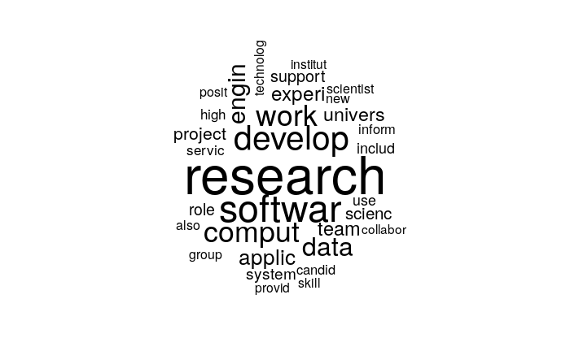

```r
wordcloud(words, min.freq = 100, max.words = 1000,
   random.order = FALSE)
mtext(side = 3, line = 3,"RSE Advert Wordcloud" )
```

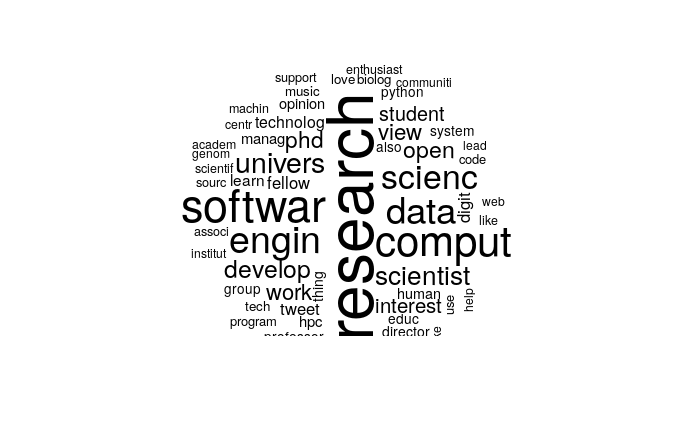

```r
wordcloud(bios.words, min.freq = 20, max.words = 100,
           random.order = FALSE)
mtext(side = 3, line = 3,"Twitter data sci/RSE" )
```

## Relative word frequencies

We can look at the relative frequencies with which words appear in the two corpuses:

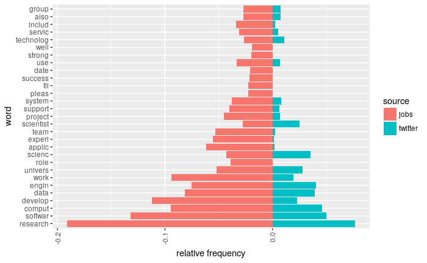

```r
combinedWords <- rbind(data.frame(source="jobs", word=words),
                       data.frame(source="twitter", word=bios.words))
# Frequency of each word in each corpus
combinedWords %<>% group_by(source, word) %>%
  summarise(freq=n()) %>%  ungroup()
# Total number of words in each corpus
totals <- combinedWords %>% group_by(source) %>% summarise(total=n())
# Calculate relative frequency of each word in each corpus
combinedWords %<>%  full_join(totals, by="source") %>%
  mutate(relfreq = as.numeric(freq)/as.numeric(total))
# Calculat the mean relative frequency of each word - we use this
# to order the factor for plot order
combinedrel <- combinedWords %>% group_by(word) %>%
  summarise(avgrel = mean(relfreq, na.rm=TRUE)) %>%
  arrange(desc(avgrel))
combinedWords$ordered <- factor(as.character(combinedWords$word),
                                levels= combinedrel$word)
combinedWords %>%
   mutate(relfreq = ifelse(source == "jobs", -relfreq, relfreq)) %>%
  filter(word %in% combinedrel$word[1:30]) %>%
  filter(word != "NA") %>%
  ggplot(aes(x=ordered, y=relfreq, group=source, fill = source)) + geom_col() +
  theme(axis.text.x = element_text(angle = 90, hjust = 1, vjust = 0.5)) +
  labs(x="word", y="relative frequency") + coord_flip()
```